# mitFinalProject

jingyun

2024-11-22

# Installing monocle3

First, install Bioconductor, and a few Bioconductor dependencies that aren’t automatically installed.

```r
if (!requireNamespace("BiocManager", quietly = TRUE))
install.packages("BiocManager")
#BiocManager::install(version = "3.14") # for R version 4.1
BiocManager::install(version = "3.20") # for R version 4.4
BiocManager::install(c('BiocGenerics', 'DelayedArray', 'DelayedMatrixStats',
                       'limma', 'lme4', 'S4Vectors', 'SingleCellExperiment',
                       'SummarizedExperiment', 'batchelor', 'HDF5Array',
                       'terra', 'ggrastr'))
```

```
## Bioconductor version 3.20 (BiocManager 1.30.25), R 4.4.2 (2024-10-31)
```

```
## Installing package(s) 'terra'
```

```
##
##  /var/folders/dp/kxk69c6d2570hht9zhlkc36w0000gn/T//Rtmp6cjCGM/downloaded_packages
```

```
## Old packages: 'httr2', 'later', 'promises', 'terra', 'usethis'
```

Second, install monocle3 through the cole-trapnell-lab GitHub, execute:

```r
install.packages("devtools")
devtools::install_github('cole-trapnell-lab/monocle3')
devtools::install_github("immunogenomics/lisi")
install.packages("Matrix")
install.packages("Seurat")
install.packages("readr")
install.packages("data.table")
```

Lastly, check that Monocle 3 was installed correctly. Start a new R session and run:

```r
library(monocle3)
library(dplyr)
#library(lisi)
library("Matrix")
library(Seurat)
library(readr)
library(data.table)
```

```r
library(ggplot2)
library(cluster)
```

# Load the data

From https://compbio.mit.edu/ad_aging_brain/ I used Cell type-specific data, Immune_cells.rds

```r
immune_cells <- readRDS("data/Immune_cells.rds")
```

Process the dataframe to match the input requirement of cds dataset. Requirements:

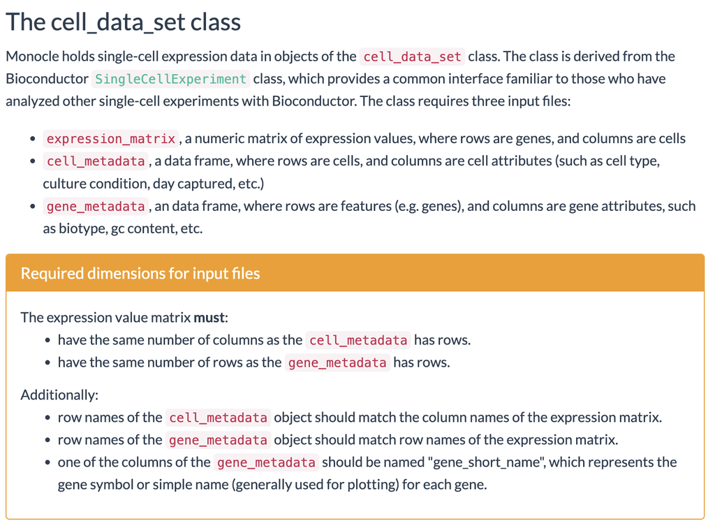

```r
expression_matrix <- GetAssayData(immune_cells, layer = "counts")
cell_metadata <- immune_cells@meta.data

#Checking the dim(expression_matrix) [1] 33538 83889
#Checking the dim(cell_metadata) [1] 83889     2
#Match the rows of cell_metadata by names of columns of expression matrix
head(rownames(cell_metadata))
```

```
## [1] "AACTTTCAGGATGGTC-1-0" "ACGGGCTCAATCAGAA-1-0" "ACTTACTGTGAAATCA-1-0"
## [4] "AGCGGTCAGATGTTAG-1-0" "AGTGAGGGTGGTAACG-1-0" "ATTACTCAGGAGTAGA-1-0"
```

```r
head(colnames(expression_matrix))
```

```
## [1] "AACTTTCAGGATGGTC-1-0" "ACGGGCTCAATCAGAA-1-0" "ACTTACTGTGAAATCA-1-0"
## [4] "AGCGGTCAGATGTTAG-1-0" "AGTGAGGGTGGTAACG-1-0" "ATTACTCAGGAGTAGA-1-0"
```

```r
rownames_match <- rownames(cell_metadata) %in% colnames(expression_matrix)
summary(rownames_match)
```

```
##    Mode    TRUE
## logical   83889
```

```r
# they all matched

# Create gene metadata
gene_metadata <- data.frame(
    gene_short_name = rownames(expression_matrix)  # Placeholder for gene symbols
)
rownames(gene_metadata) <- rownames(expression_matrix)
#Checking the dim(expression_matrix) [1] 33538 83889
#Checking the dim(gene_metadata) [1] 33538     1
```

```r
#load batch data
batch_data <- read_tsv("data/batch_mapping_deidentified.tsv")
cell_metadata$batch <- batch_data$batch[match(cell_metadata$subject, batch_data$subject)]

#load patient metadata and change the identifier to subject
patient_metadata <- read_tsv("data/dataset_652_basic_05-06-2021.tsv.gz")
linking_file <- read_tsv("data/AD427_subject_projid_mapping.tsv")
patient_metadata$subject <- linking_file$subject[match(patient_metadata$projid, linking_file$projid)]

#load most relevant columns to cell_metadata
columns_to_add <- c("cogn_global_lv", "braaksc", "ceradsc", "amyloid")
cell_metadata <- merge(cell_metadata, patient_metadata[, c("subject", columns_to_add)],
                       by = "subject", all.x = TRUE)

# Restore original row names
rownames(cell_metadata) <- colnames(expression_matrix)
```

Sample fractions of the data

```r
# Filter cell_metadata for only T-cells
tcell_metadata <- cell_metadata[cell_metadata$cell_type_high_resolution == "T cells", ]

# Ensure the columns of expression_matrix match the filtered metadata
tcell_expression_matrix <- expression_matrix[, colnames(expression_matrix) %in% rownames(tcell_metadata)]

# Check dimensions of the filtered data
dim(tcell_metadata)
```

```
## [1] 2534    7
```

```r
dim(tcell_expression_matrix)
```

```
## [1] 33538  2534
```

Visualize the cell metadata

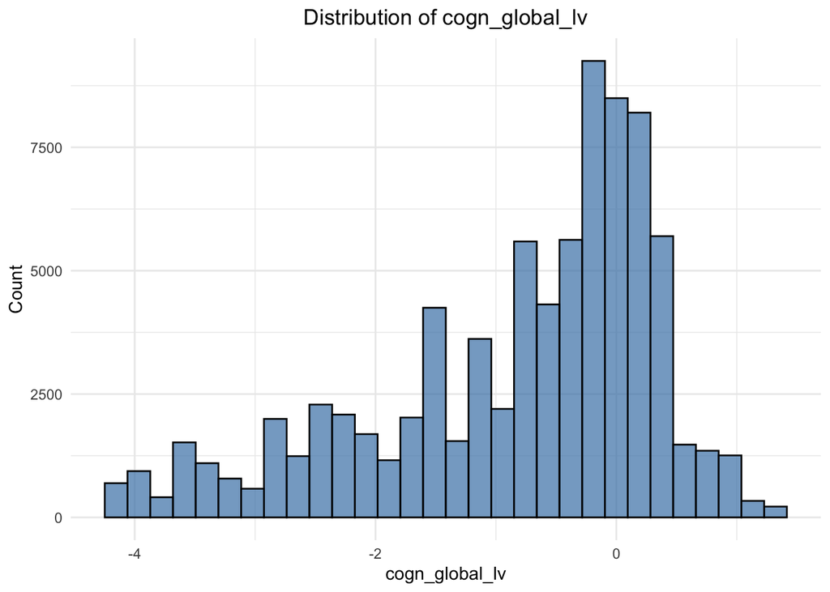

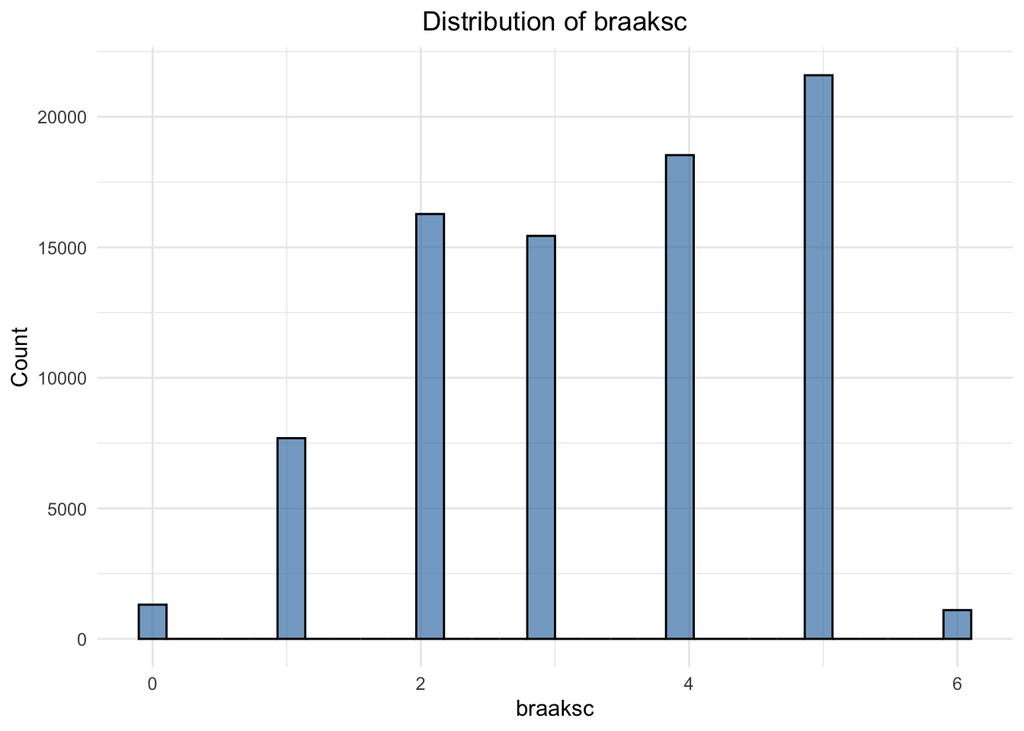

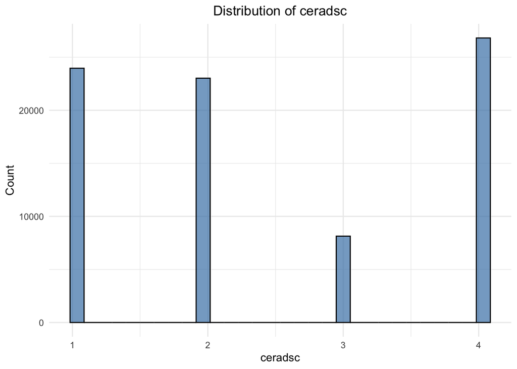

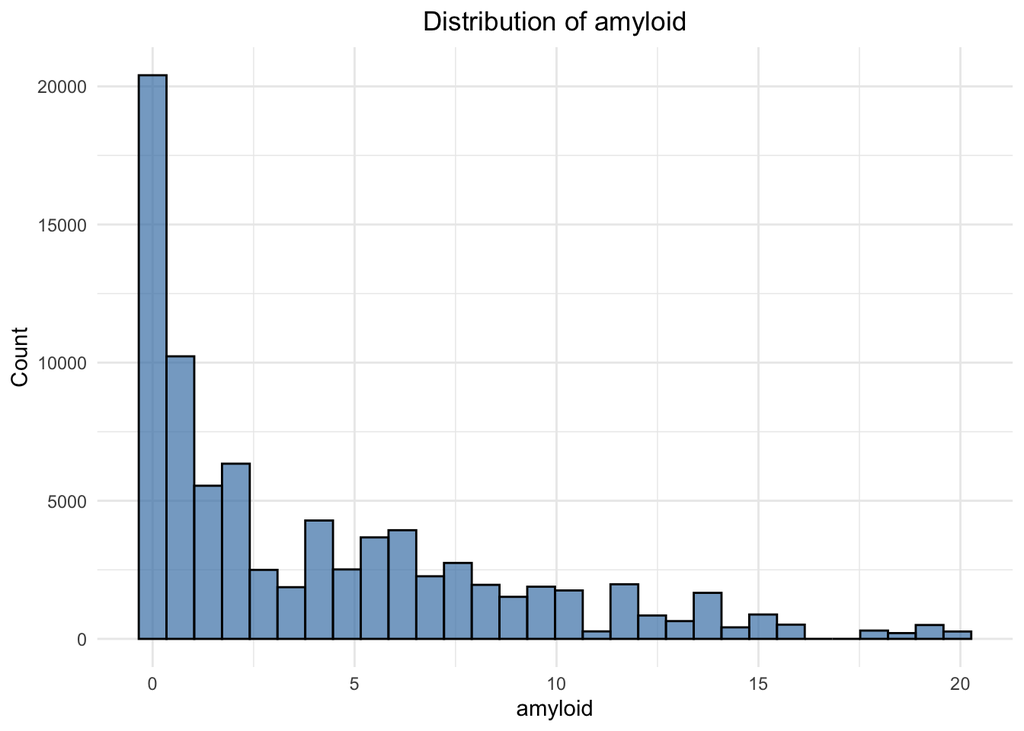

```r
# 1. Distribution of cell_type_high_resolution
numerical_vars <- c("cogn_global_lv", "braaksc", "ceradsc", "amyloid")
for (var in numerical_vars) {
  ggplot(cell_metadata, aes_string(x = var)) +
    geom_histogram(bins = 30, fill = "steelblue", color = "black", alpha = 0.7) +
    theme_minimal() +
    labs(title = paste("Distribution of", var), x = var, y = "Count") +
    theme(plot.title = element_text(hjust = 0.5)) -> p
  print(p)
}
```

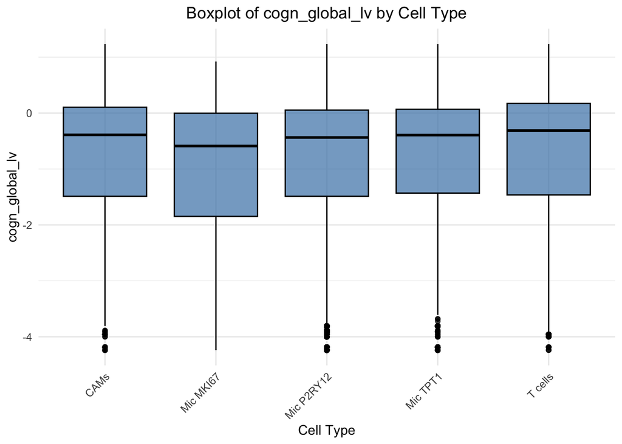

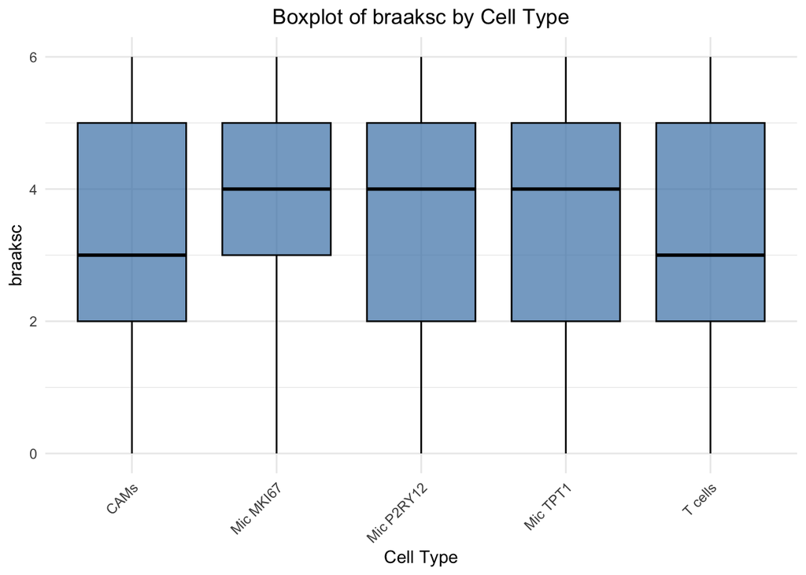

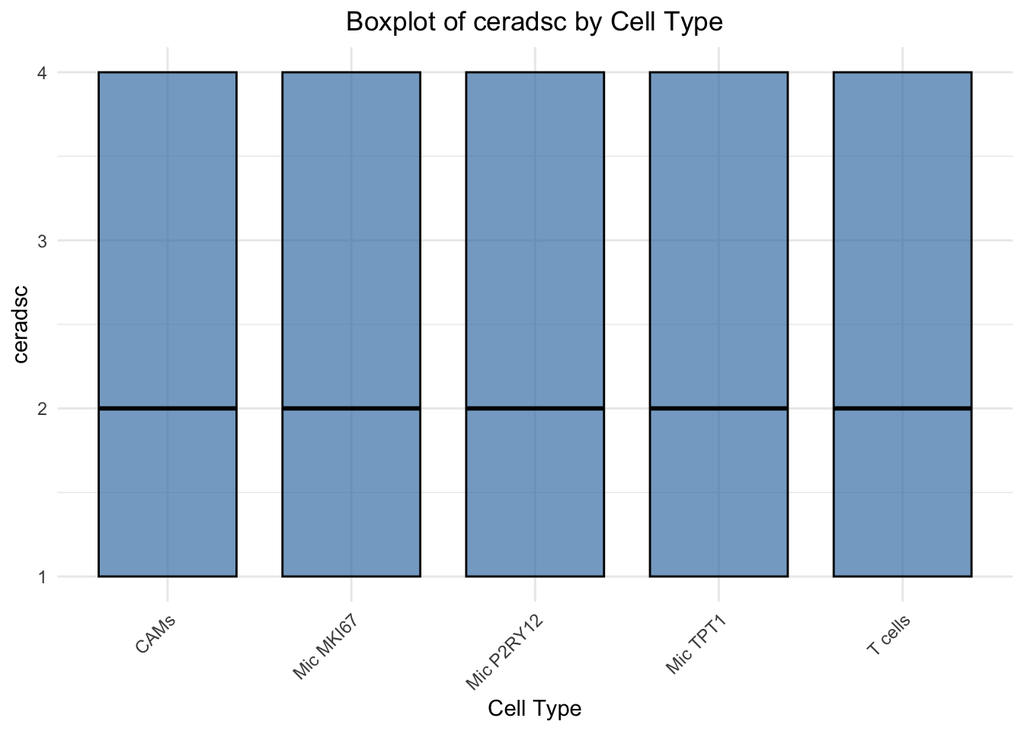

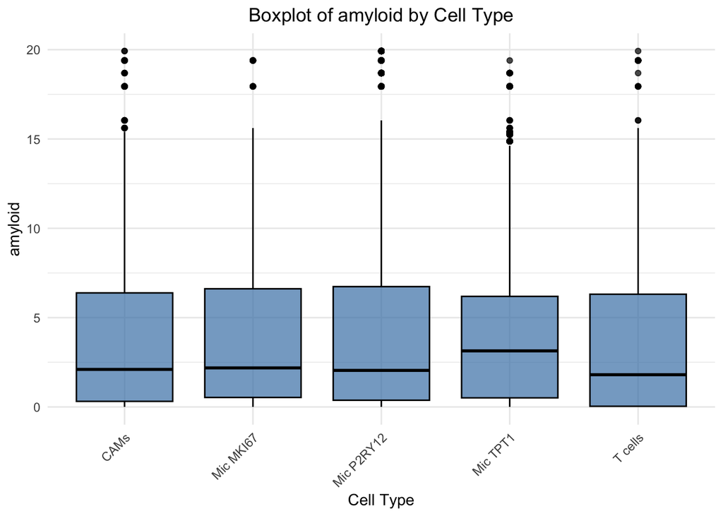

```r
for (var in numerical_vars) {
  ggplot(cell_metadata, aes_string(x = "cell_type_high_resolution", y = var)) +
    geom_boxplot(fill = "steelblue", color = "black", alpha = 0.7) +
    theme_minimal() +
    labs(title = paste("Boxplot of", var, "by Cell Type"), x = "Cell Type", y = var) +
    theme(axis.text.x = element_text(angle = 45, hjust = 1),
          plot.title = element_text(hjust = 0.5)) -> p
  print(p)
}
```

```r
# Select numerical variables and calculate correlations
cor_data <- cell_metadata[, numerical_vars]
cor_matrix <- cor(cor_data, use = "complete.obs")
cor_matrix
```

```
##                cogn_global_lv    braaksc    ceradsc    amyloid
## cogn_global_lv      1.0000000 -0.4679331  0.4320870 -0.3886277
## braaksc            -0.4679331  1.0000000 -0.6759859  0.6109521
## ceradsc             0.4320870 -0.6759859  1.0000000 -0.6564792
## amyloid            -0.3886277  0.6109521 -0.6564792  1.0000000
```

```r
cds <- new_cell_data_set(expression_matrix,
                         cell_metadata = cell_metadata,
                         gene_metadata = gene_metadata)
tcell <- new_cell_data_set(tcell_expression_matrix,
                         cell_metadata = tcell_metadata,
                         gene_metadata = gene_metadata)
```

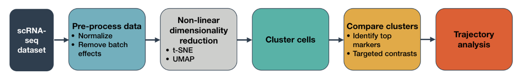

PCA the expression data -> does that reflect clinical transition? # Clustering and classifying cells

```r
cds <- preprocess_cds(tcell, num_dim = 25)
```

It’s a good idea to check that you’re using enough PCs to capture most of the variation in gene expression across all the cells in the data set. You can look at the fraction of variation explained by each PC using

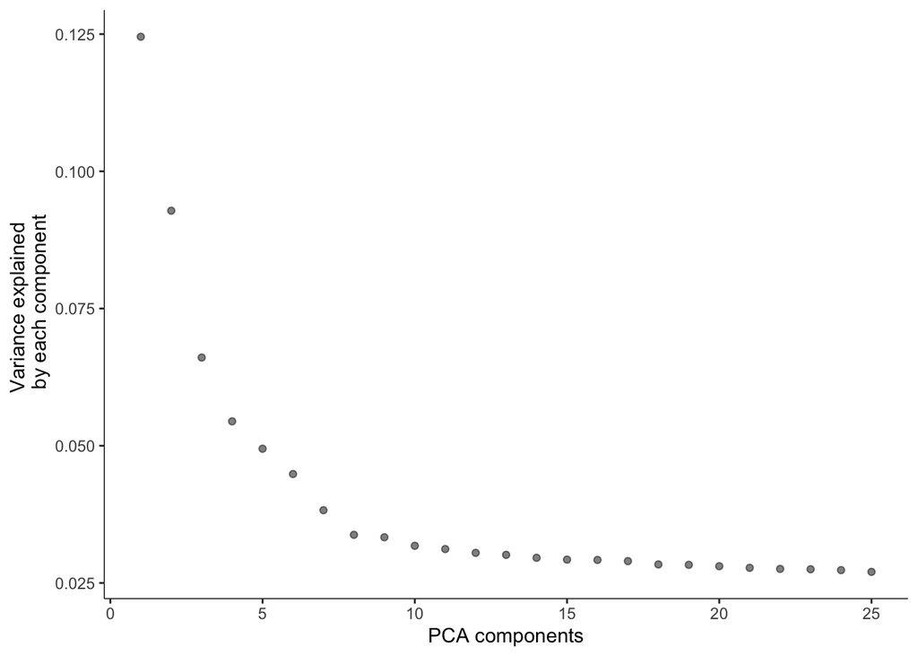

```r
plot_pc_variance_explained(cds)
```

Reduce the dimensionality and visualize the cells

```r
cds <- reduce_dimension(cds)
```

```
## No preprocess_method specified, using preprocess_method = 'PCA'
```

## Batch correction

First, observe UMAP coloring the cells by batch

```
## No trajectory to plot. Has learn_graph() been called yet?
```

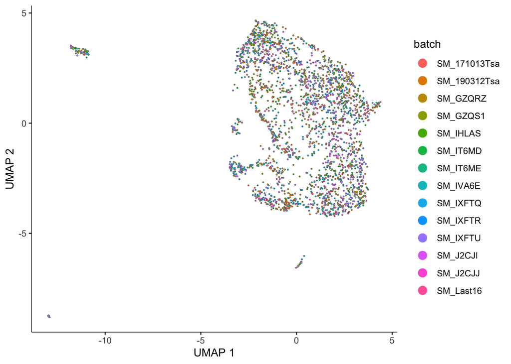

```r
plot_cells(cds, color_cells_by="batch", label_cell_groups=FALSE)
```

```r
# qualitative evaluate batch effect lisi scores...
```

```r
silhouette_score <- function(expression_matrix, cell_metadata) {
  pca_result <- prcomp(t(expression_matrix), scale. = TRUE)
  pca_data <- pca_result$x[, 1:10]

  batch_labels <- as.numeric(as.factor(cell_metadata$batch))
  dist_matrix <- as.matrix(dist(pca_data))

  silhouette_scores <- silhouette(batch_labels, dist_matrix)

  print(summary(silhouette_scores))

  return(silhouette_scores)
}

valid_columns <- apply(tcell_expression_matrix, 1, function(row) var(row) > 0)
filtered_expression_matrix <- tcell_expression_matrix[valid_columns, ]

silhouette_scores <- silhouette_score(filtered_expression_matrix, tcell_metadata)
```

```
## Found more than one class "dist" in cache; using the first, from namespace 'BiocGenerics'
```

```
## Also defined by 'spam'
```

```
## Found more than one class "dist" in cache; using the first, from namespace 'BiocGenerics'
```

```
## Also defined by 'spam'
```

```
## Silhouette of 2534 units in 14 clusters from silhouette.default(x = batch_labels, dist = dist_matrix) :
##  Cluster sizes and average silhouette widths:
##         223         305         160         170         155         193
## -0.12927678 -0.25161505 -0.12074595 -0.19571603 -0.04873913 -0.16928300
##          91         197         186         159         376         167
## -0.15428635 -0.24869073 -0.23601110 -0.09388349 -0.12032284 -0.16038446
##          77          75
## -0.16140162  0.02239216
## Individual silhouette widths:
##    Min. 1st Qu.  Median    Mean 3rd Qu.    Max.
## -0.3876 -0.2209 -0.1459 -0.1590 -0.0966  0.1397
```

```r
summary(silhouette_scores)
```

```
## Silhouette of 2534 units in 14 clusters from silhouette.default(x = batch_labels, dist = dist_matrix) :
##  Cluster sizes and average silhouette widths:
##         223         305         160         170         155         193
## -0.12927678 -0.25161505 -0.12074595 -0.19571603 -0.04873913 -0.16928300
##          91         197         186         159         376         167
## -0.15428635 -0.24869073 -0.23601110 -0.09388349 -0.12032284 -0.16038446
##          77          75
## -0.16140162  0.02239216
## Individual silhouette widths:
##    Min. 1st Qu.  Median    Mean 3rd Qu.    Max.
## -0.3876 -0.2209 -0.1459 -0.1590 -0.0966  0.1397
```

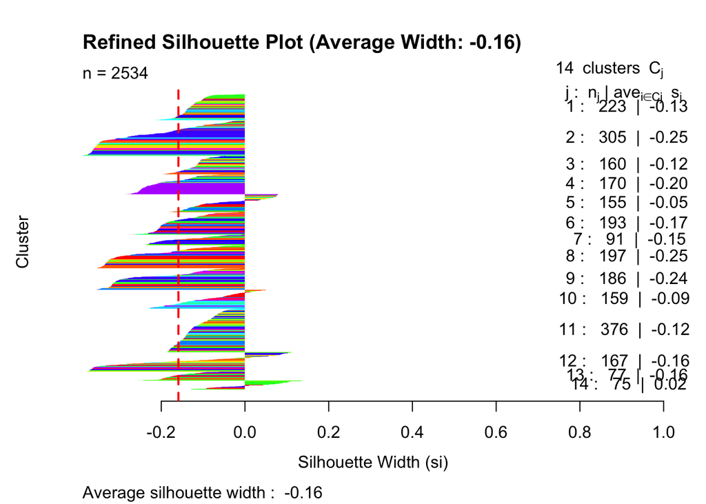

```r
graph_silhouette <- function(silhouette_scores, batch_labels) {
  avg_sil_width <- mean(silhouette_scores[, "sil_width"])

  plot(
    silhouette_scores,
    border = NA,
    col = rainbow(length(unique(batch_labels)))[batch_labels],  # Unique colors for each batch
    main = sprintf("Refined Silhouette Plot (Average Width: %.2f)", avg_sil_width),
    xlab = "Silhouette Width (si)",
    ylab = "Cluster"
  )

  # Add a line for the average silhouette width
  abline(v = avg_sil_width, col = "red", lty = 2, lwd = 2)
}

# Example use
graph_silhouette(silhouette_scores, as.numeric(as.factor(tcell_metadata$batch)))
```

```r
# Built in batch correction using monocle3
cds_align <- align_cds(cds, alignment_group = "batch")
```

```
## Aligning cells from different batches using Batchelor.
## Please remember to cite:
##   Haghverdi L, Lun ATL, Morgan MD, Marioni JC (2018). 'Batch effects in single-cell RNA-sequencing data are corrected by matching mutual nearest neighbors.' Nat. Biotechnol., 36(5), 421-427. doi: 10.1038/nbt.4091
```

```r
expression_matrix_after <- assay(cds_align)
cell_metadata_align <- colData(cds_align)

valid_columns2 <- apply(expression_matrix_after, 1, function(row) var(row) > 0)
filtered_expression_matrix2 <- expression_matrix_after[valid_columns2, ]

silhouette_after <- silhouette_score(filtered_expression_matrix2, cell_metadata_align)
```

```
## Silhouette of 2534 units in 14 clusters from silhouette.default(x = batch_labels, dist = dist_matrix) :
##  Cluster sizes and average silhouette widths:
##         223         305         160         170         155         193
## -0.12927678 -0.25161505 -0.12074595 -0.19571603 -0.04873913 -0.16928300
##          91         197         186         159         376         167
## -0.15428635 -0.24869073 -0.23601110 -0.09388349 -0.12032284 -0.16038446
##          77          75
## -0.16140162  0.02239216
## Individual silhouette widths:
##    Min. 1st Qu.  Median    Mean 3rd Qu.    Max.
## -0.3876 -0.2209 -0.1459 -0.1590 -0.0966  0.1397
```

```r
summary(silhouette_after)
```

```
## Silhouette of 2534 units in 14 clusters from silhouette.default(x = batch_labels, dist = dist_matrix) :
##  Cluster sizes and average silhouette widths:
##         223         305         160         170         155         193
## -0.12927678 -0.25161505 -0.12074595 -0.19571603 -0.04873913 -0.16928300
##          91         197         186         159         376         167
## -0.15428635 -0.24869073 -0.23601110 -0.09388349 -0.12032284 -0.16038446
##          77          75
## -0.16140162  0.02239216
## Individual silhouette widths:
##    Min. 1st Qu.  Median    Mean 3rd Qu.    Max.
## -0.3876 -0.2209 -0.1459 -0.1590 -0.0966  0.1397
```

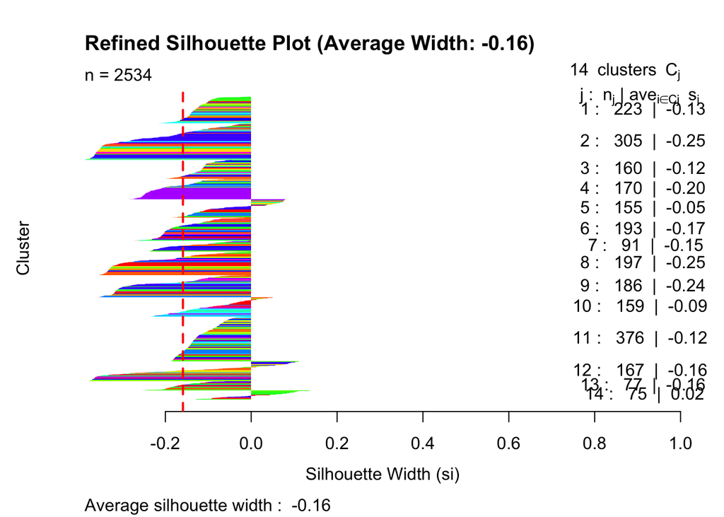

```r
graph_silhouette(silhouette_after, as.numeric(as.factor(cell_metadata_align$batch)))
```

# Trajectory Analysis

```r
cds_align <- reduce_dimension(cds_align,
                              reduction_method = "UMAP",
                              preprocess_method = "PCA", umap.metric = "cosine",
                              umap.n_neighbors = 10)
```

```
## No trajectory to plot. Has learn_graph() been called yet?
```

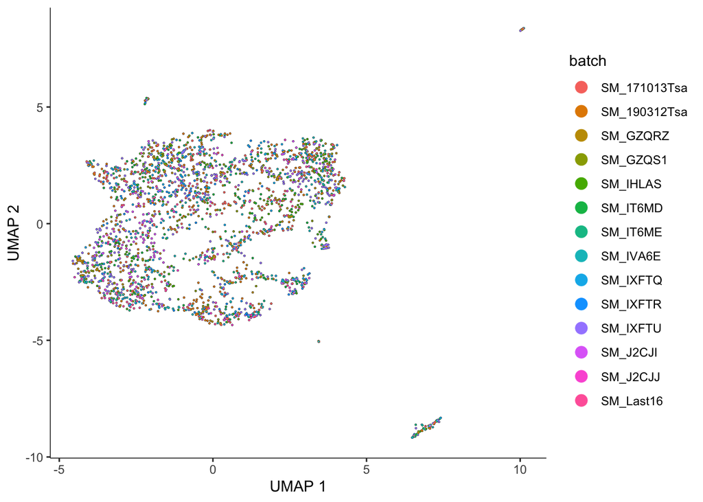

```r
plot_cells(cds_align, color_cells_by="batch", label_cell_groups=FALSE)
```

## Fit a principal graph within each partition and Order the cells in pseudotime

Pseudotime is an abstract unit of progress: it’s simply the distance between a cell and the start of the trajectory, measured along the shortest path. The trajectory’s total length is defined in terms of the total amount of transcriptional change that a cell undergoes as it moves from the starting state to the end state.

```r
#try to impute the cluster by the original one
#colData(cds_align)$custom_clusters <- colData(cds_align)$cell_type
cds_clustered <- cluster_cells(cds_align)
cds_align <- learn_graph(cds_clustered, use_partition = FALSE)
```

[output not shown]

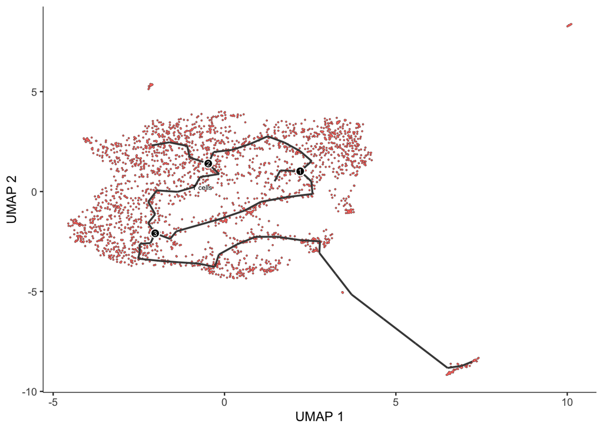

```r
trajectory_plot <- plot_cells(cds_align,
           color_cells_by = "cell_type_high_resolution",
           label_groups_by_cluster=FALSE,
           label_leaves=FALSE,
           label_branch_points=TRUE)

ggsave(
  filename = "graph/trajectory_plot.pdf",  # File name
  plot = trajectory_plot,            # The ggplot object
  width = 8,                         # Width in inches
  height = 6,                        # Height in inches
  dpi = 300                          # Resolution (optional for PDFs)
)
trajectory_plot
```

## Map the start point by clinical patients data

Instead of manually pick the start node, we can use a helper function.Essentially, we need to think of biologically relevant features or computational strategies to define the root nodes. 1. Since we have patients metadata, we can order them by the progression of disease.

The function below works by first selecting cells that match the specified diagnosis. It then determines which trajectory graph node each cell is closest to. - cds@principal_graph_aux[[“UMAP”]]$pr_graph_cell_proj_closest_vertex: Retrieves the mapping of each cell to its closest vertex in the principal graph, using the UMAP embedding. Next, it identifies the node that is most frequently associated with the selected cells, effectively representing the node most occupied by cells with the given diagnosis. Finally, it returns this node as the root, which can serve as the starting point for trajectory inference.

```r
get_earliest_principal_node <- function(cds, braaksc = 0) {

    # Find cell IDs with the specified braaksc value
  cell_ids <- which(colData(cds)[, "braaksc"] == braaksc)

  # Check if any cells match the braaksc value
  if (length(cell_ids) == 0) {
    stop("No cells with the specified braaksc value.")
  }

  # Retrieve the closest vertex information for each cell
  closest_vertex <- cds@principal_graph_aux[["UMAP"]]$pr_graph_cell_proj_closest_vertex
  closest_vertex <- as.matrix(closest_vertex[colnames(cds), ])

  # Identify the root principal node based on the most frequent vertex
  root_pr_nodes <- igraph::V(principal_graph(cds)[["UMAP"]])$name[
    as.numeric(names(which.max(table(closest_vertex[cell_ids, ]))))
  ]

  # Return the root principal node(s)
  return(root_pr_nodes)
}

# Example Usage
cds_root <- order_cells(
  cds_align,
  root_pr_nodes = get_earliest_principal_node(cds_align, braaksc = 0)
)
```

```r
evaluate_pseudotime_all_clinical <- function(cds, clinical_columns = c("braaksc", "cogn_global_lv", "ceradsc", "amyloid")) {
  # Check that all clinical columns exist in colData
  missing_columns <- setdiff(clinical_columns, colnames(colData(cds)))
  if (length(missing_columns) > 0) {
    stop(paste("The following columns are missing in colData:", paste(missing_columns, collapse = ", ")))
  }

  # Initialize a results data frame to store metrics
  results <- data.frame(
    Clinical_Score = character(),
    Spearman_Correlation = numeric(),
    MSE = numeric(),
    stringsAsFactors = FALSE
  )

  # Iterate through each clinical score column
  for (clinical_column in clinical_columns) {
    # Extract pseudotime and clinical data
    pseudotime <- pseudotime(cds)  # Extract pseudotime
    clinical_data <- colData(cds)[, clinical_column]

    # Filter out NA values
    valid_indices <- !is.na(pseudotime) & !is.na(clinical_data)
    pseudotime_valid <- pseudotime[valid_indices]
    clinical_data_valid <- clinical_data[valid_indices]

    # Skip if no valid data points are available
    if (length(pseudotime_valid) == 0 || length(clinical_data_valid) == 0) {
      next
    }

    # Compute metrics
    spearman_correlation <- cor(pseudotime_valid, clinical_data_valid, method = "spearman")
    mse <- mean((pseudotime_valid - clinical_data_valid)^2)

    # Append metrics to results data frame
    results <- rbind(results, data.frame(
      Clinical_Score = clinical_column,
      Spearman_Correlation = spearman_correlation,
      MSE = mse,
      stringsAsFactors = FALSE
    ))
  }

  # Return the results data frame
  return(results)
}

# Example usage: Evaluate pseudotime relationships with clinical scores
clinical_scores <- c("braaksc", "cogn_global_lv", "ceradsc", "amyloid")
results <- evaluate_pseudotime_all_clinical(cds_root, clinical_scores)

# View the results
print(results)
```

```
##   Clinical_Score Spearman_Correlation      MSE
## 1        braaksc         -0.001937743 39.07955
## 2 cogn_global_lv         -0.008232649 86.97782
## 3        ceradsc         -0.053950952 45.15893
## 4        amyloid          0.074749736 49.98810
```

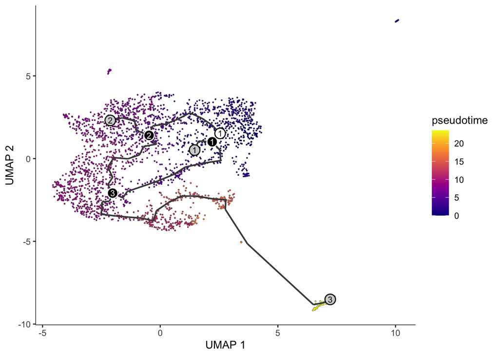

```r
pseudotime <- plot_cells(cds_root,
           color_cells_by = "pseudotime",
           label_cell_groups=FALSE,
           label_leaves=TRUE,
           label_branch_points=TRUE,
           graph_label_size=3)
ggsave(
  filename = "graph/pseudotime_plot.pdf",  # File name
  plot = pseudotime,            # The ggplot object
  width = 8,                         # Width in inches
  height = 6,                        # Height in inches
  dpi = 300                          # Resolution (optional for PDFs)
)
pseudotime
```

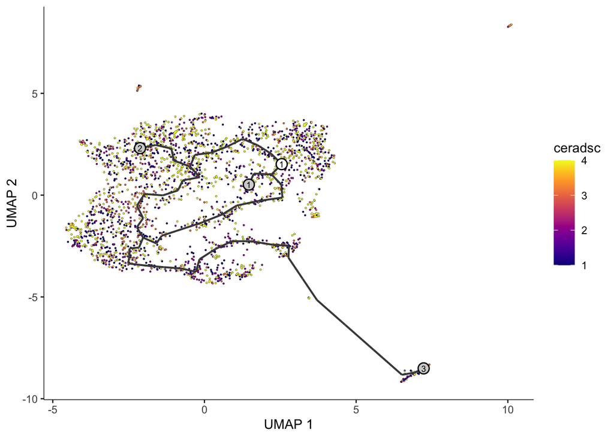

```r
ceradsc <- plot_cells(cds_root,
           color_cells_by = "ceradsc",
           label_cell_groups=FALSE,
           label_leaves=TRUE,
           label_branch_points=FALSE,
           graph_label_size=2.5)
ggsave(
  filename = "graph/ceradsc_plot.pdf",  # File name
  plot = ceradsc,            # The ggplot object
  width = 8,                         # Width in inches
  height = 6,                        # Height in inches
  dpi = 300                          # Resolution (optional for PDFs)
)
ceradsc
```